# Clustering and Identification of Gene Markers Report

The purpose of this analysis is to assign cells into different clusters based on the similarity of transcription profiles followed by identification of genes predominantly expressed in those clusters. The analysis is based on the **Seurat 3.2.2** R-package and consists of four steps:

1. Loading Single Cell RNA-seq Expression Data
2. Quality Control and Filtering
3. Normalization with Variance Stabilization and PCA
4. Clustering and Identification of Gene Markers

### Load Single Cell RNA-seq Expression Data

In this initial step, the gene-to-cell count matrix is loaded into the Seurat object. Initial filtering is performed in a way that all the cells that express less than **200** genes were removed from the further analysis as well as all the genes that are expressed in less than **3** cells. Specifically, **1884305** (**98.66%**) cells were removed, and **25541** (**1.34%**) cells were used for further analysis.

### Quality Control and Filtering

Further filtering of the data was performed based on several quality metrics (Fig 1, 2):

- **Genes detected per cell** - For high-quality data, the density plot should contain a single large peak that represents cells that were encapsulated. If there is a small shoulder to the right of the major peak, or a bimodal distribution of the cells, that can indicate that there is a set of cells that failed for some reason or that there are biologically different types of cells (i.e. quiescent cell populations, less complex cells...), and/or one type is much smaller than the other (i.e. cells with high counts may be cells that are larger in size).
- **UMI counts (transcripts) per cell** - The total number of UMI molecules detected within a cell correlates strongly with **Genes detected per cell**.
- **Mitochondrial counts percent** - High percent of mitochondrial counts in the cells could be indicative of damaged/dying cells whose cytoplasmic mRNA has leaked out through a broken membrane, and thus, only mRNA located in the mitochondria is still conserved.
- **Novelty (complexity)** - Calculated as log10(Genes per UMI), this metric may help detecting contamination with low complexity cell types like red blood cells.

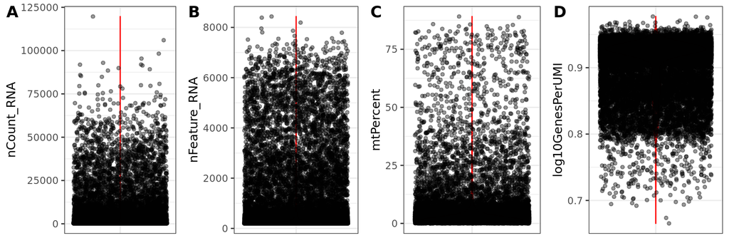

**Fig 1. Distribution (represented by violin plots) of: A - UMI counts per cell, B - Gene counts per cell, C - Percent of mitochondrial counts per cell, D - Novelty score (complexity).**

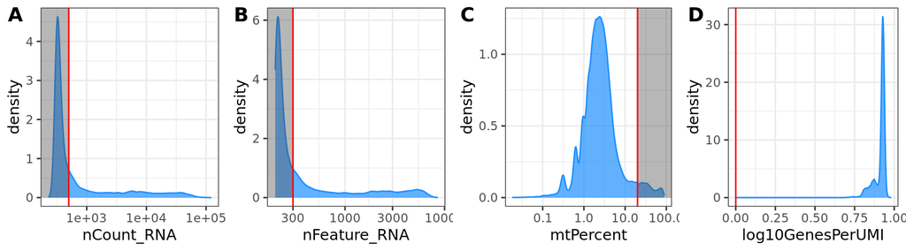

**Fig 2. Distribution (represented by density plots) of: A - UMI counts per cell, B - Gene counts per cell, C - Percent of mitochondrial counts per cell, D - Novelty score (complexity). Red line indicates the filtering threshold for each parameter. Gray shadow represents removed data.**

##### Further analysis included only cells in which:

- **number of UMI counts** is higher than **500**
- **number of detected genes** is higher than **300**
- **percent of mitochondrial counts** is lower than **20**

Based on this criteria, **18264** (**71.51%**) cells were removed and **7277** (**28.49%**) cells were used for further analysis.

### Normalization with Variance Stabilization and PCA

The purpose of this step is to keep the major sources of variation in the dataset that should define the cell types, while restricting the variation due to uninteresting sources of variation.

In this analysis, the Seurat `SCTransform` method was used for normalisation, estimation of the variance of the raw filtered data, and identification of the most variable genes. In addition, the same method was used to regress out variation due to **sequencing depth (number of UMIs), number of features (genes), cell cycle phase and mitochondrial expression**. Figure 3 shows whether a cell cycle represents a significant source of variation in the dataset.

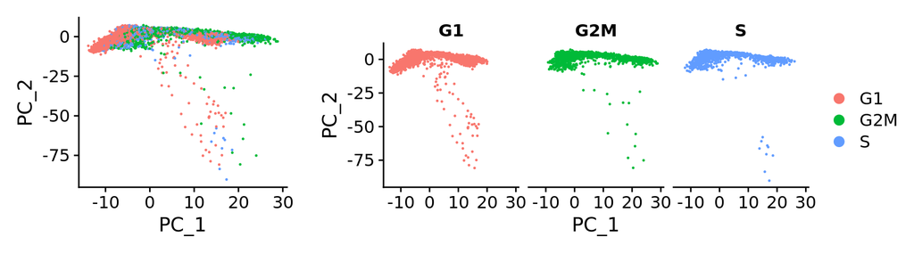

**Fig 3. The Differences due to cell cycle phase.**

After regression of unwanted variation, Principal component analysis (PCA) is used to emphasise variation as well as similarity, and to bring out strong patterns in a dataset by reducing dimensionality of the data. To overcome the extensive technical noise in the expression of any single gene for scRNA-seq data, Seurat assigns cells to clusters based on their PCA scores derived from the expression of the integrated most variable genes, with each PC essentially representing a "metagene" that combines information across a correlated gene set.

Because the `SCTransform` method estimates the variance better than earlier methods and does not frequently include the sources of technical variation in the higher PCs, selection of PCs is no longer as important as it used to be. In theory, with `SCTransform`, the more PCs we choose the more variation is accounted for when performing the clustering, but this can increase the time required to perform the clustering. For this analysis, the first **30** PCs will be used to generate the clusters (Fig 4).

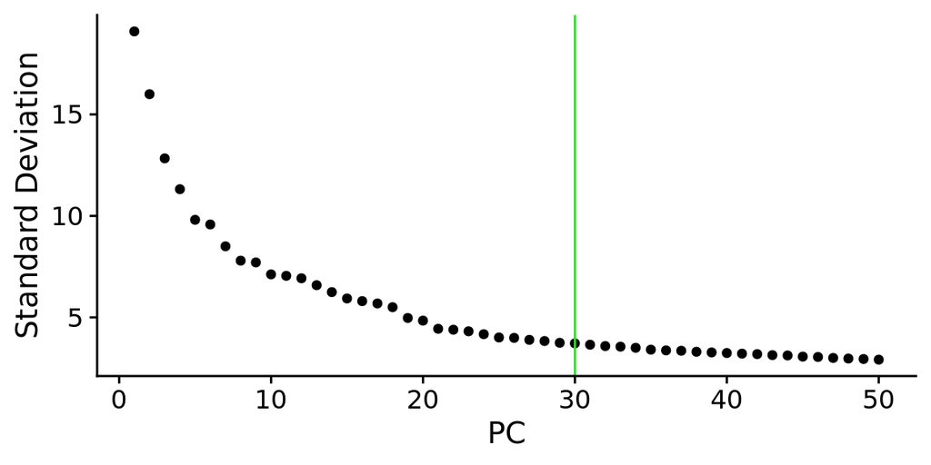

**Fig 4. The elbow plot visualizes the standard deviation of each PC. Green line represents the number of PCs used for clustering analysis.**

### Clustering and Identification of Gene Markers

To cluster cells, the `FindClusters` method implements some of the modularity optimisation techniques (by default Louvain algorithm). Resolution parameter in `FindClusters` sets the 'granularity' of the downstream clustering, with increased values leading to a higher number of clusters. Additionally, a non-linear dimensional reduction technique UMAP, can be used to visually explore clustering results. Cells within the graph-based clusters should co-localize on the UMAP plot (Fig 5).

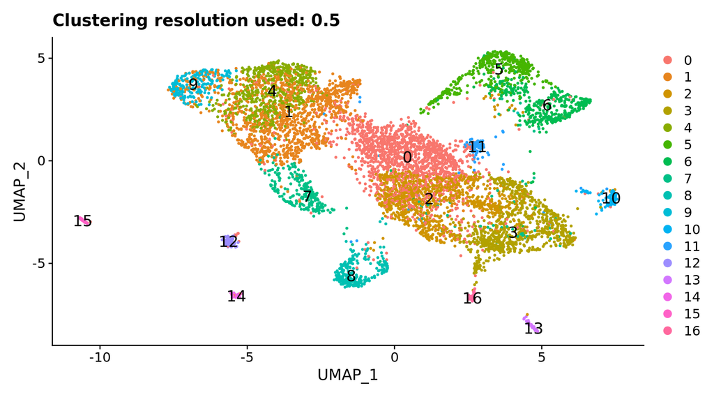

**Fig 5. Visualisation of clustering results using UMAP plot.**

The main problem when conducting clustering analysis is how many clusters to use. This is controlled by a resolution parameter provided to the clustering algorithm. Statistics designed to assist with making the choice of clustering resolution typically either compare two clusterings or score a single clustering. Here we create a clustering tree displaying the relationships across a range of resolutions. The user may change the resolution values by setting the **Clustree resolutions** parameter in the workflow settings.

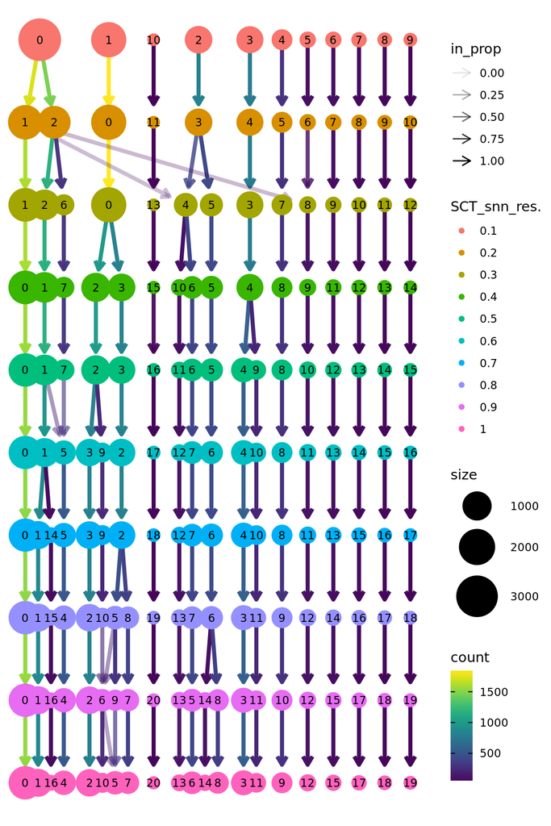

**Fig 6. The clustering tree that visualizes the clustering labels across a range of resolution values.**

Seurat performs differential expression to identify gene markers of a single cluster, compared to all other cells. The `FindAllMarkers` method automates this process for all clusters. Two arguments are important for marker selection. The `min.pct` argument requires a feature (gene) to be detected at a minimum percentage in either of the two groups of cells and the `logfc.threshold` argument requires a feature (gene) to be differentially expressed (on average) by some amount between the two groups. In this analysis, these two parameters were set to **0.1** and **0.25**, respectively, and only positive markers were considered (`only.pos` argument was set to TRUE).

Top 10 markers for each cluster are shown in the table below.

|  | gene_id | gene_symbol | cluster | avg_logFC | p_val | p_val_adj |
| --- | --- | --- | --- | --- | --- | --- |
| 1 | ENSMUSG00000021939 | Ctsb | 0 | 0.25 | 1.6e-138 | 2.65e-134 |
| 2 | ENSMUSG00000105361 | AY036118 | 0 | 0.4 | 1.77e-131 | 2.94e-127 |
| 3 | ENSMUSG00000035202 | Lars2 | 0 | 0.37 | 3.67e-89 | 6.11e-85 |
| 4 | ENSMUSG00000060802 | B2m | 0 | 0.29 | 4.69e-84 | 7.81e-80 |
| 5 | ENSMUSG00000001020 | S100a4 | 1 | 0.83 | 7.23e-286 | 1.2e-281 |
| 6 | ENSMUSG00000001025 | S100a6 | 1 | 0.75 | 3.49e-281 | 5.8e-277 |
| 7 | ENSMUSG00000068220 | Lgals1 | 1 | 0.7 | 1.05e-271 | 1.75e-267 |
| 8 | ENSMUSG00000041841 | Rpl37 | 1 | 0.59 | 1.07e-237 | 1.78e-233 |
| 9 | ENSMUSG00000030432 | Rpl28 | 1 | 0.6 | 1.7e-233 | 2.82e-229 |
| 10 | ENSMUSG00000058600 | Rpl30 | 1 | 0.6 | 2.72e-228 | 4.53e-224 |

[output cut: 154 more lines]

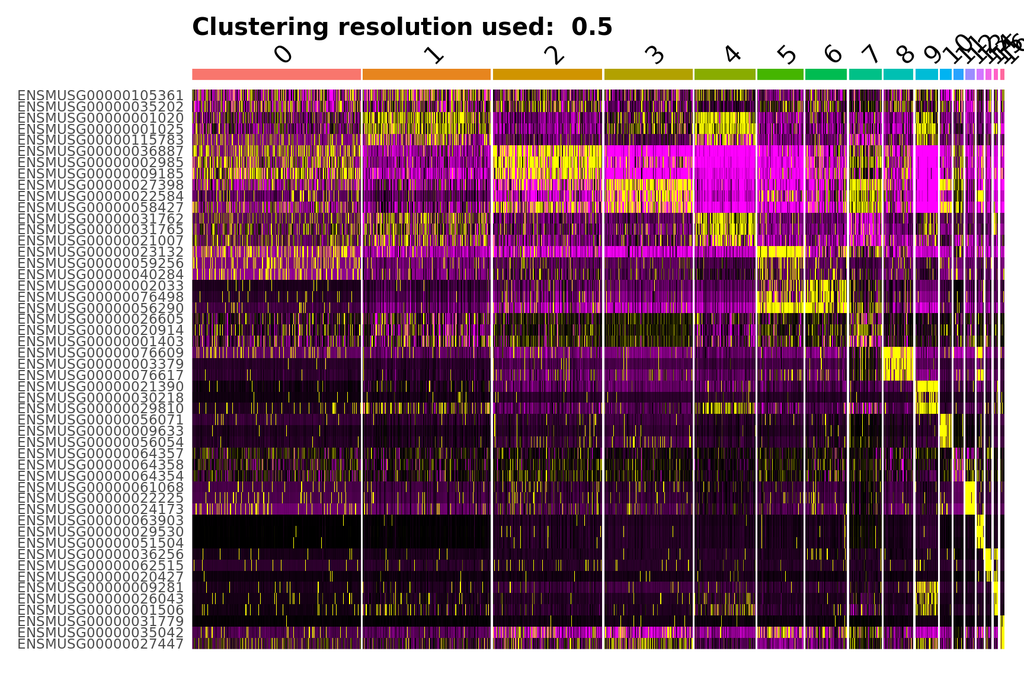

**Fig 7. Heatmap plot showing expression patterns of three marker genes per each cluster.**